# Madeira Workshop Test File

Author

Published

May 14, 2025

## Load packages needed for the workshop

```r
packages <- c("amt",
              "sf",
              "tidyverse",
              "lubridate",
              "TwoStepCLogit",
              "glmmTMB",
              "tictoc",
              "broom",
              "here",
              "terra",
              "moveHMM",
              "boot",
              "survival",
              "momentuHMM",
              "ctmm")

sapply(packages, require, character.only = TRUE)
```

[output not shown]

```
          amt            sf     tidyverse     lubridate TwoStepCLogit
         TRUE          TRUE          TRUE          TRUE          TRUE
      glmmTMB        tictoc         broom          here         terra
         TRUE          TRUE          TRUE          TRUE          TRUE
      moveHMM          boot      survival    momentuHMM          ctmm
         TRUE          TRUE          TRUE          TRUE          TRUE
```

## Short tests

Don’t worry too much about what the code is doing in these various sections (we will go over similar code during the workshop). A this point, just make sure everything runs without any errors!

### Test of SSF methods

Read in fisher data from the `R`esource-and-Step-Selection-Analyses/Data` subdirectory and select one individual’s data for an SSF.

```r
fisherdat <- read_csv(
  here("Resource-and-Step-Selection-Analyses/Data", "fisher_data.csv")) |>
      dplyr::filter(id == 1465)
```

Create a track with an appropriate coordinate reference system.

```r
fisher_trk <- make_track(fisherdat, x, y, t, crs = 4326) |>
      amt::transform_coords(5070)
```

Resample the track to 10 minutes with a tolerance of 2 minutes.

```r
fisher_trk <- fisher_trk |>
  track_resample(rate = minutes(10), tolerance = seconds(120))
```

Read in the landuse raster and reclassify to two categories (wet forests and other).

```r
landuse <- rast(
  here("Resource-and-Step-Selection-Analyses/Data",  "landuse_study_area.tif"))
wet_forests <- landuse %in% c(90, 95)
names(wet_forests) <- "forest"
```

Prepare a “steps” representation of the data for fitting SSFs.

```r
fisher_ssf <- fisher_trk |>
                 steps_by_burst() |> # steps version of the data set
                 random_steps() |>  # random steps for fitting model
                 extract_covariates(wet_forests) |> # extract coordinates
                 mutate(cos_ta = cos(ta_), log_sl = log(sl_))
```

Fit SSF and look at summary output:

```r
fisherSSF <-  fit_clogit(case_ ~ forest + cos_ta + sl_ + log_sl + strata(step_id_),
                         data = fisher_ssf)
summary(fisherSSF)
```

```
Call:
coxph(formula = Surv(rep(1, 5753L), case_) ~ forest + cos_ta +
    sl_ + log_sl + strata(step_id_), data = data, method = "exact")

  n= 5753, number of events= 523

                 coef  exp(coef)   se(coef)      z Pr(>|z|)
forestTRUE  0.6979177  2.0095638  0.1271917  5.487 4.09e-08 ***
cos_ta     -0.0196929  0.9804998  0.0665281 -0.296    0.767
sl_        -0.0001591  0.9998409  0.0005321 -0.299    0.765
log_sl      0.0659138  1.0681346  0.0626161  1.053    0.292
---
Signif. codes:  0 '***' 0.001 '**' 0.01 '*' 0.05 '.' 0.1 ' ' 1

           exp(coef) exp(-coef) lower .95 upper .95
forestTRUE    2.0096     0.4976    1.5662     2.579
cos_ta        0.9805     1.0199    0.8606     1.117
sl_           0.9998     1.0002    0.9988     1.001
log_sl        1.0681     0.9362    0.9448     1.208

Concordance= 0.559  (se = 0.016 )
Likelihood ratio test= 32.36  on 4 df,   p=2e-06
Wald test            = 31.45  on 4 df,   p=2e-06
Score (logrank) test = 32.04  on 4 df,   p=2e-06
```

### Test of HMM methods

Read in elk data of Morales et al. (2004) from Ecological Archives.

```r
trackData <- read.table("https://esapubs.org/archive/ecol/E085/072/elk_data.txt",sep="\t",header=TRUE)
# remove blank rows
trackData <- trackData[1:735,]
```

Convert locations from meters to km.

```r
trackData$Easting <- trackData$Easting/1000
trackData$Northing <- trackData$Northing/1000
```

Prepare data for analysis and fit using moveHMM.

```r
colnames(trackData)[1] <- "ID"
elkData <- moveHMM::prepData(trackData,type="UTM",coordNames=c("Easting","Northing"))

# specify initial values for optimization
shape <- c(1,2) # step shape (two parameters: one for each state)
scale <- c(0.5,5) # step scale
zeromass0 <- c(0.01,0.001) # step zero-mass (needed to account for zero step lengths)
stepPar0 <- c(shape,scale,zeromass0)
angleMean0 <- c(pi,0) # angle mean
rho <- c(0.2,0.75) # angle concentration
anglePar0 <- c(angleMean0,rho)

# fit "double switch with covariates" model
doubleSwitch1 <- moveHMM::fitHMM(data=elkData,nbStates=2,stepPar0=stepPar0,anglePar0=anglePar0,stepDist="gamma",angleDist="vm",stationary=TRUE)
doubleSwitch1
```

```
Value of the maximum log-likelihood: -1893.706

Step length parameters:
----------------------
              state 1      state 2
mean      0.373627562 3.218320e+00
sd        0.398105230 4.376049e+00
zero-mass 0.002011902 2.067241e-08

Turning angle parameters:
------------------------
                 state 1    state 2
mean          -3.0064783 0.04352836
concentration  0.5934281 0.19992732

Regression coeffs for the transition probabilities:
--------------------------------------------------
             1 -> 2    2 -> 1
intercept -2.329458 -1.460821

Transition probability matrix:
-----------------------------
          [,1]       [,2]
[1,] 0.9112875 0.08871251
[2,] 0.1883418 0.81165816

Initial distribution:
--------------------
[1] 0.6798011 0.3201989
```

Prepare data for analysis and fit using momentuHMM.

```r
elkData <- momentuHMM::prepData(trackData,coordNames=c("Easting","Northing"))

# fit "double switch with covariates" model
doubleSwitch2 <- momentuHMM::fitHMM(data=elkData,nbStates=2,Par0=list(step=stepPar0,angle=anglePar0),dist=list(step="gamma",angle="vm"),estAngleMean=list(angle=TRUE),stationary=TRUE)
doubleSwitch2
```

```
Value of the maximum log-likelihood: -1893.706


step parameters:
----------------
             state 1      state 2
mean     0.373627536 3.218319e+00
sd       0.398105194 4.376048e+00
zeromass 0.002011903 2.085270e-08

angle parameters:
-----------------
                 state 1    state 2
mean          -3.0064782 0.04352789
concentration  0.5934282 0.19992702

Regression coeffs for the transition probabilities:
---------------------------------------------------
               1 -> 2    2 -> 1
(Intercept) -2.329459 -1.460822

Transition probability matrix:
------------------------------
          state 1    state 2
state 1 0.9112876 0.08871242
state 2 0.1883416 0.81165840

Initial distribution:
---------------------
 state 1  state 2
0.679801 0.320199
```

Verify crawl and interpolation work

```r
utils::example("crawlWrap","momentuHMM",run.dontrun = TRUE)
```

```
crwlWr> # extract simulated obsData from example data
crwlWr> obsData <- miExample$obsData

crwlWr> # error ellipse model
crwlWr> err.model <- list(x= ~ ln.sd.x - 1, y =  ~ ln.sd.y - 1, rho =  ~ error.corr)

crwlWr> # Fit crwMLE models to obsData and predict locations
crwlWr> # at default intervals for both individuals
crwlWr> crwOut1 <- crawlWrap(obsData=obsData,
crwlWr+          theta=c(4,0),fixPar=c(1,1,NA,NA),
crwlWr+          err.model=err.model,attempts=100)
Fitting 2 track(s) using crawl::crwMLE...
DONE

Predicting locations (and uncertainty) for 2 track(s) using crawl::crwPredict... DONE

crwlWr> # Fit the same crwMLE models and predict locations
crwlWr> # at same intervals but specify for each individual using lists
crwlWr> crwOut2 <- crawlWrap(obsData=obsData,
crwlWr+          theta=list(c(4,0),c(4,0)), fixPar=list(c(1,1,NA,NA),c(1,1,NA,NA)),
crwlWr+          err.model=list(err.model,err.model),
crwlWr+          predTime=list('1'=seq(1,633),'2'=seq(1,686)))
Fitting 2 track(s) using crawl::crwMLE...
DONE

Predicting locations (and uncertainty) for 2 track(s) using crawl::crwPredict... DONE
```

```r
head(crwOut2$crwPredict[,c("ID","time","mu.x","mu.y","x","y","cov1","cov2")],7)
```

```
  ID     time     mu.x     mu.y         x         y        cov1      cov2
1  1 1.000000 1.810942 8.420102  2.685085  16.01634  0.01874617 1.2155138
3  1 1.009380 1.832254 8.356186  2.249121  22.86060          NA        NA
4  1 1.072285 2.035508 7.932051 -3.717187 -20.25539          NA        NA
5  1 1.236261 3.452186 7.125191  7.791898 -19.26293          NA        NA
6  1 1.393954 4.356609 6.866829  1.148864  34.82248          NA        NA
7  1 1.854668 5.086169 5.891313  4.866935  11.30140          NA        NA
8  1 2.000000 5.259395 5.270578        NA        NA -0.18425254 0.3308765
```

### Test for ctmm methods

Read-in African buffalo (Syncerus caffer) data from Kruger National Park:

```r
data(buffalo)
data_buffalo <- buffalo$Cilla[1:300, ] # first 300 rows to speed up run time
```

Calculate variogram:

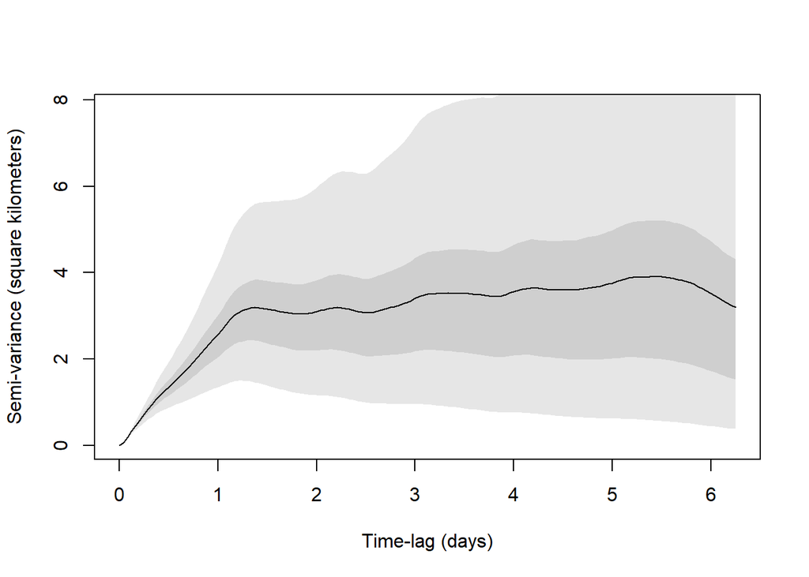

```r
svf <- variogram(data_buffalo)
plot(svf, level = c(0.5, 0.95)) #  with 50% and 95% CIs
```

Select best-fit movement model:

```r
guess_buffalo <- ctmm::ctmm.guess(data_buffalo, interactive = FALSE)
fit_buffalo <- ctmm::ctmm.fit(data_buffalo, guess_buffalo)
summary(fit_buffalo)
```

```
$name
[1] "OUF anisotropic"

$DOF
     mean      area diffusion     speed
  9.24181  14.78218  63.53578 230.58345

$CI
                                        low       est      high
area (square kilometers)          38.293645 68.754402 107.98199
τ[position] (hours)                8.922509 17.193698  33.13230
τ[velocity] (minutes)             46.023106 58.393402  74.08864
speed (kilometers/day)            15.618963 16.696584  17.77328
diffusion (square kilometers/day)  7.312653  9.505099  11.98061
```

Run Autocorrelated Kernel density Estimation (AKDE):

```r
AKDE <- ctmm::akde(data_buffalo, fit_buffalo)
summary(AKDE)
```

```
$DOF
     area bandwidth
 14.78218  20.96360

$CI
                              low      est     high
area (square kilometers) 37.82876 67.91972 106.6711

attr(,"class")
[1] "area"
```

```
DOP values missing. Assuming DOP=1.
```

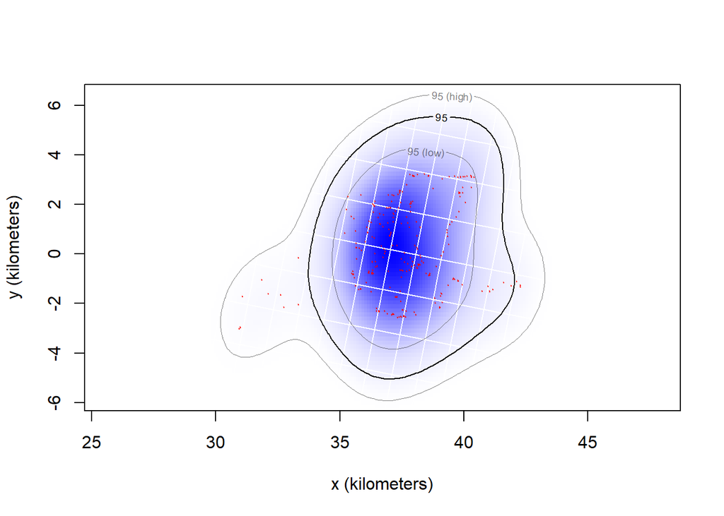

```r
plot(data_buffalo, UD = AKDE)
```